# Supervised Learning - Foundations Project: ReCell

## Problem Statement

### Business Context

Buying and selling used phones and tablets used to be something that happened on a handful of online marketplace sites. But the used and refurbished device market has grown considerably over the past decade, and a new IDC (International Data Corporation) forecast predicts that the used phone market would be worth \$52.7bn by 2023 with a compound annual growth rate (CAGR) of 13.6% from 2018 to 2023. This growth can be attributed to an uptick in demand for used phones and tablets that offer considerable savings compared with new models.

Refurbished and used devices continue to provide cost-effective alternatives to both consumers and businesses that are looking to save money when purchasing one. There are plenty of other benefits associated with the used device market. Used and refurbished devices can be sold with warranties and can also be insured with proof of purchase. Third-party vendors/platforms, such as Verizon, Amazon, etc., provide attractive offers to customers for refurbished devices. Maximizing the longevity of devices through second-hand trade also reduces their environmental impact and helps in recycling and reducing waste. The impact of the COVID-19 outbreak may further boost this segment as consumers cut back on discretionary spending and buy phones and tablets only for immediate needs.

### Objective

The rising potential of this comparatively under-the-radar market fuels the need for an ML-based solution to develop a dynamic pricing strategy for used and refurbished devices. ReCell, a startup aiming to tap the potential in this market, has hired you as a data scientist. They want you to analyze the data provided and build a linear regression model to predict the price of a used phone/tablet and identify factors that significantly influence it.

### Data Description

The data contains the different attributes of used/refurbished phones and tablets. The data was collected in the year 2021. The detailed data dictionary is given below.

- brand_name: Name of manufacturing brand
- os: OS on which the device runs
- screen_size: Size of the screen in cm
- 4g: Whether 4G is available or not
- 5g: Whether 5G is available or not
- main_camera_mp: Resolution of the rear camera in megapixels
- selfie_camera_mp: Resolution of the front camera in megapixels
- int_memory: Amount of internal memory (ROM) in GB
- ram: Amount of RAM in GB
- battery: Energy capacity of the device battery in mAh
- weight: Weight of the device in grams
- release_year: Year when the device model was released
- days_used: Number of days the used/refurbished device has been used
- normalized_new_price: Normalized price of a new device of the same model in euros
- normalized_used_price: Normalized price of the used/refurbished device in euros

## Importing necessary libraries

```python
# Installing the libraries with the specified version.
# uncomment and run the following line if Google Colab is being used
import warnings
warnings.filterwarnings("ignore")
!pip install scikit-learn==1.3.2 seaborn==0.13.1 matplotlib==3.8.0 numpy==1.26.4 pandas==2.2.2 -q --user
```

```python
# Installing the libraries with the specified version.
# uncomment and run the following lines if Jupyter Notebook is being used
#!pip install scikit-learn==1.2.2 seaborn==0.11.1 matplotlib==3.3.4 numpy==1.24.3 pandas==1.5.2 -q --user
```

**Note**: *After running the above cell, kindly restart the notebook kernel and run all cells sequentially from the start again.*

```python
import pandas as pd
import numpy as np
import seaborn as sns
import matplotlib.pyplot as plt
#import warnings
#warnings.filterwarnings('ignore')
```

## Loading the dataset

```python
from google.colab import drive
drive.mount('/content/drive')
```

```python
df = pd.read_csv('/content/drive/MyDrive/project 3/used_device_data 2.csv')
df.head()
```

|  | brand_name | os | screen_size | 4g | 5g | main_camera_mp | selfie_camera_mp | int_memory | ram | battery | weight | release_year | days_used | normalized_used_price | normalized_new_price |
| --- | --- | --- | --- | --- | --- | --- | --- | --- | --- | --- | --- | --- | --- | --- | --- |
| 0 | Honor | Android | 14.50 | yes | no | 13.0 | 5.0 | 64.0 | 3.0 | 3020.0 | 146.0 | 2020 | 127 | 4.307572 | 4.715100 |
| 1 | Honor | Android | 17.30 | yes | yes | 13.0 | 16.0 | 128.0 | 8.0 | 4300.0 | 213.0 | 2020 | 325 | 5.162097 | 5.519018 |
| 2 | Honor | Android | 16.69 | yes | yes | 13.0 | 8.0 | 128.0 | 8.0 | 4200.0 | 213.0 | 2020 | 162 | 5.111084 | 5.884631 |
| 3 | Honor | Android | 25.50 | yes | yes | 13.0 | 8.0 | 64.0 | 6.0 | 7250.0 | 480.0 | 2020 | 345 | 5.135387 | 5.630961 |
| 4 | Honor | Android | 15.32 | yes | no | 13.0 | 8.0 | 64.0 | 3.0 | 5000.0 | 185.0 | 2020 | 293 | 4.389995 | 4.947837 |

```python
df.tail()
```

|  | brand_name | os | screen_size | 4g | 5g | main_camera_mp | selfie_camera_mp | int_memory | ram | battery | weight | release_year | days_used | normalized_used_price | normalized_new_price |
| --- | --- | --- | --- | --- | --- | --- | --- | --- | --- | --- | --- | --- | --- | --- | --- |
| 3449 | Asus | Android | 15.34 | yes | no | NaN | 8.0 | 64.0 | 6.0 | 5000.0 | 190.0 | 2019 | 232 | 4.492337 | 6.483872 |
| 3450 | Asus | Android | 15.24 | yes | no | 13.0 | 8.0 | 128.0 | 8.0 | 4000.0 | 200.0 | 2018 | 541 | 5.037732 | 6.251538 |
| 3451 | Alcatel | Android | 15.80 | yes | no | 13.0 | 5.0 | 32.0 | 3.0 | 4000.0 | 165.0 | 2020 | 201 | 4.357350 | 4.528829 |
| 3452 | Alcatel | Android | 15.80 | yes | no | 13.0 | 5.0 | 32.0 | 2.0 | 4000.0 | 160.0 | 2020 | 149 | 4.349762 | 4.624188 |
| 3453 | Alcatel | Android | 12.83 | yes | no | 13.0 | 5.0 | 16.0 | 2.0 | 4000.0 | 168.0 | 2020 | 176 | 4.132122 | 4.279994 |

## Data Overview

- Observations
- Sanity checks

```python
df.info()
```

```
<class 'pandas.core.frame.DataFrame'>
RangeIndex: 3454 entries, 0 to 3453
Data columns (total 15 columns):
 #   Column                 Non-Null Count  Dtype
---  ------                 --------------  -----
 0   brand_name             3454 non-null   object
 1   os                     3454 non-null   object
 2   screen_size            3454 non-null   float64
 3   4g                     3454 non-null   object
 4   5g                     3454 non-null   object
 5   main_camera_mp         3275 non-null   float64
 6   selfie_camera_mp       3452 non-null   float64
 7   int_memory             3450 non-null   float64
 8   ram                    3450 non-null   float64
 9   battery                3448 non-null   float64
 10  weight                 3447 non-null   float64
 11  release_year           3454 non-null   int64
 12  days_used              3454 non-null   int64
 13  normalized_used_price  3454 non-null   float64
 14  normalized_new_price   3454 non-null   float64
dtypes: float64(9), int64(2), object(4)
memory usage: 404.9+ KB
```

```python
df.isnull().sum()
```

|  | 0 |
| --- | --- |
| brand_name | 0 |
| os | 0 |
| screen_size | 0 |
| 4g | 0 |
| 5g | 0 |
| main_camera_mp | 179 |
| selfie_camera_mp | 2 |
| int_memory | 4 |
| ram | 4 |
| battery | 6 |
| weight | 7 |
| release_year | 0 |
| days_used | 0 |
| normalized_used_price | 0 |
| normalized_new_price | 0 |

**dtype:** int64

## Exploratory Data Analysis (EDA)

- EDA is an important part of any project involving data.
- It is important to investigate and understand the data better before building a model with it.
- A few questions have been mentioned below which will help you approach the analysis in the right manner and generate insights from the data.
- A thorough analysis of the data, in addition to the questions mentioned below, should be done.

**Questions**:

1. What does the distribution of normalized used device prices look like?
2. What percentage of the used device market is dominated by Android devices?
3. The amount of RAM is important for the smooth functioning of a device. How does the amount of RAM vary with the brand?
4. A large battery often increases a device's weight, making it feel uncomfortable in the hands. How does the weight vary for phones and tablets offering large batteries (more than 4500 mAh)?
5. Bigger screens are desirable for entertainment purposes as they offer a better viewing experience. How many phones and tablets are available across different brands with a screen size larger than 6 inches?
6. A lot of devices nowadays offer great selfie cameras, allowing us to capture our favorite moments with loved ones. What is the distribution of devices offering greater than 8MP selfie cameras across brands?
7. Which attributes are highly correlated with the normalized price of a used device?

## Data Preprocessing

- Missing value treatment
- Feature engineering (if needed)
- Outlier detection and treatment (if needed)
- Preparing data for modeling
- Any other preprocessing steps (if needed)

```python
df.isnull().sum()
```

|  | 0 |
| --- | --- |
| brand_name | 0 |
| os | 0 |
| screen_size | 0 |
| 4g | 0 |
| 5g | 0 |
| main_camera_mp | 179 |
| selfie_camera_mp | 2 |
| int_memory | 4 |
| ram | 4 |
| battery | 6 |
| weight | 7 |
| release_year | 0 |
| days_used | 0 |
| normalized_used_price | 0 |
| normalized_new_price | 0 |

**dtype:** int64

```python
df.columns
```

```
Index(['brand_name', 'os', 'screen_size', '4g', '5g', 'main_camera_mp',
       'selfie_camera_mp', 'int_memory', 'ram', 'battery', 'weight',
       'release_year', 'days_used', 'normalized_used_price',
       'normalized_new_price'],
      dtype='object')
```

```python
for k in df.columns:
  if df[k].isnull().any():
    df[k]=df[k].fillna(df[k].mean())
df.isnull().sum()
```

|  | 0 |
| --- | --- |
| brand_name | 0 |
| os | 0 |
| screen_size | 0 |
| 4g | 0 |
| 5g | 0 |
| main_camera_mp | 0 |
| selfie_camera_mp | 0 |
| int_memory | 0 |
| ram | 0 |
| battery | 0 |
| weight | 0 |
| release_year | 0 |
| days_used | 0 |
| normalized_used_price | 0 |
| normalized_new_price | 0 |

**dtype:** int64

```python
df.describe()
```

|  | screen_size | main_camera_mp | selfie_camera_mp | int_memory | ram | battery | weight | release_year | days_used | normalized_used_price | normalized_new_price |
| --- | --- | --- | --- | --- | --- | --- | --- | --- | --- | --- | --- |
| count | 3454.000000 | 3454.000000 | 3454.000000 | 3454.000000 | 3454.000000 | 3454.000000 | 3454.000000 | 3454.000000 | 3454.000000 | 3454.000000 | 3454.000000 |
| mean | 13.713115 | 9.460208 | 6.554229 | 54.573099 | 4.036122 | 3133.402697 | 182.751871 | 2015.965258 | 674.869716 | 4.364712 | 5.233107 |
| std | 3.805280 | 4.688986 | 6.968353 | 84.923140 | 1.364314 | 1298.553176 | 88.323566 | 2.298455 | 248.580166 | 0.588914 | 0.683637 |
| min | 5.080000 | 0.080000 | 0.000000 | 0.010000 | 0.020000 | 500.000000 | 69.000000 | 2013.000000 | 91.000000 | 1.536867 | 2.901422 |
| 25% | 12.700000 | 5.000000 | 2.000000 | 16.000000 | 4.000000 | 2100.000000 | 142.000000 | 2014.000000 | 533.500000 | 4.033931 | 4.790342 |
| 50% | 12.830000 | 9.460208 | 5.000000 | 32.000000 | 4.000000 | 3000.000000 | 160.000000 | 2015.500000 | 690.500000 | 4.405133 | 5.245892 |
| 75% | 15.340000 | 13.000000 | 8.000000 | 64.000000 | 4.000000 | 4000.000000 | 185.000000 | 2018.000000 | 868.750000 | 4.755700 | 5.673718 |
| max | 30.710000 | 48.000000 | 32.000000 | 1024.000000 | 12.000000 | 9720.000000 | 855.000000 | 2020.000000 | 1094.000000 | 6.619433 | 7.847841 |

## EDA

- It is a good idea to explore the data once again after manipulating it.

```python
df
```

|  | brand_name | os | screen_size | 4g | 5g | main_camera_mp | selfie_camera_mp | int_memory | ram | battery | weight | release_year | days_used | normalized_used_price | normalized_new_price |
| --- | --- | --- | --- | --- | --- | --- | --- | --- | --- | --- | --- | --- | --- | --- | --- |
| 0 | Honor | Android | 14.50 | yes | no | 13.000000 | 5.0 | 64.0 | 3.0 | 3020.0 | 146.0 | 2020 | 127 | 4.307572 | 4.715100 |
| 1 | Honor | Android | 17.30 | yes | yes | 13.000000 | 16.0 | 128.0 | 8.0 | 4300.0 | 213.0 | 2020 | 325 | 5.162097 | 5.519018 |
| 2 | Honor | Android | 16.69 | yes | yes | 13.000000 | 8.0 | 128.0 | 8.0 | 4200.0 | 213.0 | 2020 | 162 | 5.111084 | 5.884631 |
| 3 | Honor | Android | 25.50 | yes | yes | 13.000000 | 8.0 | 64.0 | 6.0 | 7250.0 | 480.0 | 2020 | 345 | 5.135387 | 5.630961 |
| 4 | Honor | Android | 15.32 | yes | no | 13.000000 | 8.0 | 64.0 | 3.0 | 5000.0 | 185.0 | 2020 | 293 | 4.389995 | 4.947837 |
| ... | ... | ... | ... | ... | ... | ... | ... | ... | ... | ... | ... | ... | ... | ... | ... |
| 3449 | Asus | Android | 15.34 | yes | no | 9.460208 | 8.0 | 64.0 | 6.0 | 5000.0 | 190.0 | 2019 | 232 | 4.492337 | 6.483872 |
| 3450 | Asus | Android | 15.24 | yes | no | 13.000000 | 8.0 | 128.0 | 8.0 | 4000.0 | 200.0 | 2018 | 541 | 5.037732 | 6.251538 |
| 3451 | Alcatel | Android | 15.80 | yes | no | 13.000000 | 5.0 | 32.0 | 3.0 | 4000.0 | 165.0 | 2020 | 201 | 4.357350 | 4.528829 |
| 3452 | Alcatel | Android | 15.80 | yes | no | 13.000000 | 5.0 | 32.0 | 2.0 | 4000.0 | 160.0 | 2020 | 149 | 4.349762 | 4.624188 |
| 3453 | Alcatel | Android | 12.83 | yes | no | 13.000000 | 5.0 | 16.0 | 2.0 | 4000.0 | 168.0 | 2020 | 176 | 4.132122 | 4.279994 |

3454 rows × 15 columns

```python
df_copy = df.copy()
df_copy
```

|  | brand_name | os | screen_size | 4g | 5g | main_camera_mp | selfie_camera_mp | int_memory | ram | battery | weight | release_year | days_used | normalized_used_price | normalized_new_price |
| --- | --- | --- | --- | --- | --- | --- | --- | --- | --- | --- | --- | --- | --- | --- | --- |
| 0 | Honor | Android | 14.50 | yes | no | 13.000000 | 5.0 | 64.0 | 3.0 | 3020.0 | 146.0 | 2020 | 127 | 4.307572 | 4.715100 |
| 1 | Honor | Android | 17.30 | yes | yes | 13.000000 | 16.0 | 128.0 | 8.0 | 4300.0 | 213.0 | 2020 | 325 | 5.162097 | 5.519018 |
| 2 | Honor | Android | 16.69 | yes | yes | 13.000000 | 8.0 | 128.0 | 8.0 | 4200.0 | 213.0 | 2020 | 162 | 5.111084 | 5.884631 |
| 3 | Honor | Android | 25.50 | yes | yes | 13.000000 | 8.0 | 64.0 | 6.0 | 7250.0 | 480.0 | 2020 | 345 | 5.135387 | 5.630961 |
| 4 | Honor | Android | 15.32 | yes | no | 13.000000 | 8.0 | 64.0 | 3.0 | 5000.0 | 185.0 | 2020 | 293 | 4.389995 | 4.947837 |
| ... | ... | ... | ... | ... | ... | ... | ... | ... | ... | ... | ... | ... | ... | ... | ... |
| 3449 | Asus | Android | 15.34 | yes | no | 9.460208 | 8.0 | 64.0 | 6.0 | 5000.0 | 190.0 | 2019 | 232 | 4.492337 | 6.483872 |
| 3450 | Asus | Android | 15.24 | yes | no | 13.000000 | 8.0 | 128.0 | 8.0 | 4000.0 | 200.0 | 2018 | 541 | 5.037732 | 6.251538 |
| 3451 | Alcatel | Android | 15.80 | yes | no | 13.000000 | 5.0 | 32.0 | 3.0 | 4000.0 | 165.0 | 2020 | 201 | 4.357350 | 4.528829 |
| 3452 | Alcatel | Android | 15.80 | yes | no | 13.000000 | 5.0 | 32.0 | 2.0 | 4000.0 | 160.0 | 2020 | 149 | 4.349762 | 4.624188 |
| 3453 | Alcatel | Android | 12.83 | yes | no | 13.000000 | 5.0 | 16.0 | 2.0 | 4000.0 | 168.0 | 2020 | 176 | 4.132122 | 4.279994 |

3454 rows × 15 columns

### What does the distribution of normalized used device prices look like?

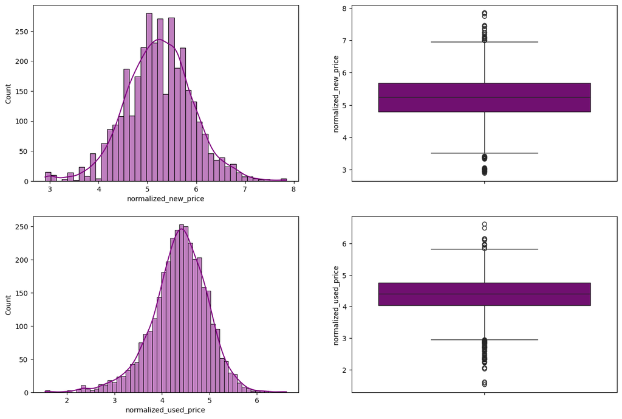

```python
axs, figure = plt.subplots(2, 2, figsize=(15, 10))
sns.histplot(df['normalized_used_price'], ax=figure[1][0], kde=True, color="purple")
sns.histplot(df['normalized_new_price'], ax=figure[0][0], kde=True, color="purple")
sns.boxplot(df['normalized_used_price'], ax=figure[1][1], color="purple")
sns.boxplot(df['normalized_new_price'], ax=figure[0][1], color="purple")
plt.show()
```

```python
import pandas as pd

quartiles = df['normalized_used_price'].quantile([0.025, 0.25, 0.5, 0.75, 0.95, 0.975])

print(quartiles)
```

```
0.025    3.034109
0.250    4.033931
0.500    4.405133
0.750    4.755700
0.950    5.236616
0.975    5.414648
Name: normalized_used_price, dtype: float64
```

#### Conclusion: According to the graphs of the normalized distribution of used cell phone prices, it is determined that 95% of the data is found in a price range (in euros) between 3.03 and 5.41 with a median of 4.4. There are unusual prices, as they are above the upper whisker and below the lower whisker, which may be due to inflated prices or devices in poor condition, which could be considered outliers.

```python
df_copy['release_year'].value_counts()
```

| release_year | count |
| --- | --- |
| 2014 | 642 |
| 2013 | 570 |
| 2015 | 515 |
| 2019 | 446 |
| 2016 | 383 |
| 2018 | 322 |
| 2017 | 299 |
| 2020 | 277 |

**dtype:** int64

```python
df_copy[df_copy['normalized_used_price']<3.034109]['brand_name'].value_counts()
```

| brand_name | count |
| --- | --- |
| Others | 17 |
| Celkon | 16 |
| Micromax | 15 |
| Nokia | 13 |
| Alcatel | 10 |
| Lava | 4 |
| Samsung | 3 |
| LG | 2 |
| Realme | 2 |
| Spice | 2 |
| Huawei | 1 |
| Karbonn | 1 |
| Motorola | 1 |

**dtype:** int64

```python
df_copy[df_copy['normalized_used_price']<3.034109]['4g'].value_counts()
```

| 4g | count |
| --- | --- |
| no | 81 |
| yes | 6 |

**dtype:** int64

```python
df_copy[df_copy['normalized_used_price']<3.034109]['5g'].value_counts()
```

| 5g | count |
| --- | --- |
| no | 87 |

**dtype:** int64

```python
df_copy[df_copy['normalized_used_price']>5.414648]['release_year'].value_counts()
```

| release_year | count |
| --- | --- |
| 2019 | 33 |
| 2020 | 30 |
| 2018 | 13 |
| 2016 | 5 |
| 2015 | 2 |
| 2014 | 2 |
| 2017 | 1 |
| 2013 | 1 |

**dtype:** int64

#### After analyzing these outliers, it's possible that the low prices are due to low-end references of little-known brands, which is reinforced by the fact that most of them do not have a 4g network and none have 5g, or to external variables such as the condition of the device. On the other hand, cell phones with higher prices may be due to having been launched in a recent year.

### What percentage of the used device market is dominated by Android devices?

```python
df_copy[df_copy['os']=="Android"].shape[0]/df_copy.shape[0]
```

```
0.9305153445280834
```

93% of the used device market is dominated by Android devices

### The amount of RAM is important for the smooth functioning of a device. How does the amount of RAM vary with the brand?

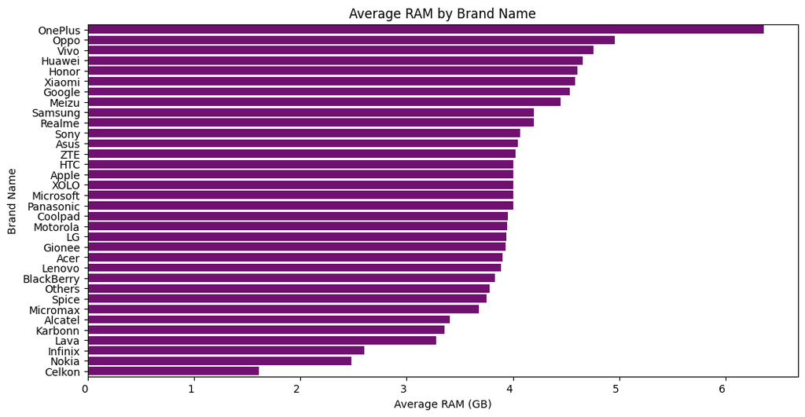

```python
import seaborn as sns
import matplotlib.pyplot as plt

brand_ram_mean = df.groupby('brand_name')['ram'].mean().reset_index().sort_values(by='ram', ascending=False)

plt.figure(figsize=(12, 6))
sns.barplot(y='brand_name', x='ram', data=brand_ram_mean, color='purple')

plt.xlabel('Average RAM (GB)')
plt.ylabel('Brand Name')
plt.title('Average RAM by Brand Name')

plt.xticks(rotation=0, ha='right')

plt.show()
```

```python
df_copy.groupby("brand_name")["ram"].mean().sort_values(ascending=False)
```

| brand_name | ram |
| --- | --- |
| OnePlus | 6.363636 |
| Oppo | 4.961240 |
| Vivo | 4.756410 |
| Huawei | 4.655378 |
| Honor | 4.603448 |
| Xiaomi | 4.583333 |
| Google | 4.533333 |
| Meizu | 4.451613 |
| Samsung | 4.199413 |
| Realme | 4.195122 |
| Sony | 4.069767 |
| Asus | 4.049180 |
| ZTE | 4.023214 |
| HTC | 4.000000 |
| Apple | 4.000000 |
| XOLO | 4.000000 |
| Microsoft | 4.000000 |
| Panasonic | 4.000000 |
| Coolpad | 3.954545 |
| Motorola | 3.943396 |
| LG | 3.936567 |
| Gionee | 3.933036 |
| Acer | 3.901961 |
| Lenovo | 3.885965 |
| BlackBerry | 3.829545 |
| Others | 3.777888 |
| Spice | 3.750000 |
| Micromax | 3.679487 |
| Alcatel | 3.407025 |
| Karbonn | 3.353448 |
| Lava | 3.277778 |
| Infinix | 2.600000 |
| Nokia | 2.481269 |
| Celkon | 1.613636 |

**dtype:** float64

### A large battery often increases a device's weight, making it feel uncomfortable in the hands. How does the weight vary for phones and tablets offering large batteries (more than 4500 mAh)?

```python
df_battery=df[df['battery']>4500]
```

```python
df_battery_mean=df_battery.groupby("battery")["weight"].mean().sort_values(ascending=False)
```

```python
df_battery_mean = df_battery_mean.to_frame() # Convert Series to DataFrame
df_battery_mean['new_index'] = range(len(df_battery_mean))
df_battery_mean = df_battery_mean.set_index(['new_index', df_battery_mean.index])
df_battery_mean
```

| new_index | battery | weight |
| --- | --- | --- |
| 0 | 8380.0 | 855.000000 |
| 1 | 9500.0 | 743.033333 |
| 2 | 8400.0 | 655.000000 |
| 3 | 9300.0 | 637.000000 |
| 4 | 9720.0 | 636.000000 |
| ... | ... | ... |
| 67 | 4520.0 | 206.500000 |
| 68 | 5020.0 | 205.100000 |
| 69 | 5180.0 | 195.000000 |
| 70 | 6180.0 | 167.500000 |
| 71 | 5870.0 | 150.000000 |

72 rows × 1 columns

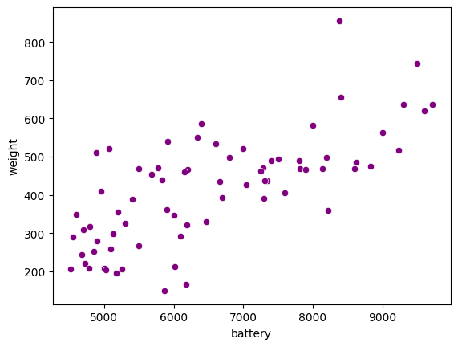

```python
sns.scatterplot(x="battery", y='weight', data=df_battery_mean, color="purple")
plt.show()
```

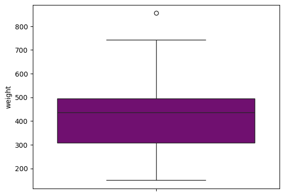

```python
sns.boxplot(y="weight", data=df_battery_mean, color="purple")
plt.show()
```

```python
quartiles_2 = df_battery_mean['weight'].quantile([0.025, 0.25, 0.5, 0.75, 0.95, 0.975])

print(quartiles_2)
```

```
0.025    188.8125
0.250    307.5250
0.500    437.0000
0.750    494.5500
0.950    636.4500
0.975    674.8075
Name: weight, dtype: float64
```

#### 95% of the Weight for batteries larger than 4500mAh is between 188.81 and 674.80 (in grams)

### Bigger screens are desirable for entertainment purposes as they offer a better viewing experience. How many phones and tablets are available across different brands with a screen size larger than 6 inches?

```python
df_screen=df[df['screen_size']>6]
df_screen.groupby("brand_name")["screen_size"].count().sort_values(ascending=False)
```

| brand_name | screen_size |
| --- | --- |
| Others | 479 |
| Samsung | 334 |
| Huawei | 251 |
| LG | 197 |
| Lenovo | 171 |
| ZTE | 140 |
| Xiaomi | 132 |
| Oppo | 129 |
| Asus | 122 |
| Vivo | 117 |
| Honor | 116 |
| Alcatel | 115 |
| HTC | 110 |
| Micromax | 108 |
| Motorola | 106 |
| Sony | 86 |
| Nokia | 72 |
| Meizu | 62 |
| Gionee | 56 |
| Acer | 51 |
| XOLO | 49 |
| Panasonic | 47 |
| Realme | 41 |
| Apple | 39 |
| Lava | 36 |
| Spice | 30 |
| Karbonn | 29 |
| Celkon | 25 |
| Microsoft | 22 |
| OnePlus | 22 |
| Coolpad | 22 |
| BlackBerry | 21 |
| Google | 15 |
| Infinix | 10 |

**dtype:** int64

### A lot of devices nowadays offer great selfie cameras, allowing us to capture our favorite moments with loved ones. What is the distribution of devices offering greater than 8MP selfie cameras across brands?

```python
df_selfie=df[df['selfie_camera_mp']>8]
df_selfie.groupby("brand_name")["selfie_camera_mp"].count().sort_values(ascending=False)
```

| brand_name | selfie_camera_mp |
| --- | --- |
| Huawei | 87 |
| Vivo | 78 |
| Oppo | 75 |
| Xiaomi | 63 |
| Samsung | 57 |
| Honor | 41 |
| Others | 34 |
| LG | 32 |
| Motorola | 26 |
| Meizu | 24 |
| ZTE | 20 |
| HTC | 20 |
| OnePlus | 18 |
| Realme | 18 |
| Sony | 14 |
| Lenovo | 14 |
| Nokia | 10 |
| Asus | 6 |
| Infinix | 4 |
| Gionee | 4 |
| Coolpad | 3 |
| Micromax | 2 |
| Panasonic | 2 |
| BlackBerry | 2 |
| Acer | 1 |

**dtype:** int64

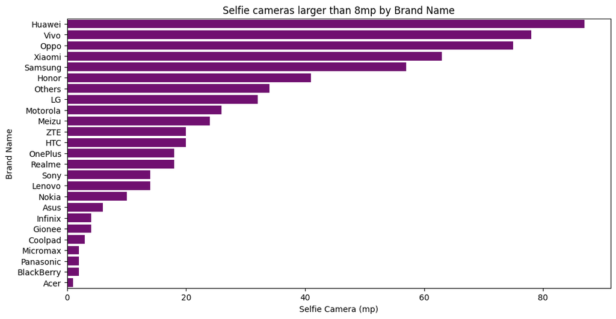

```python
brand_selfie_count = df_selfie.groupby('brand_name')['selfie_camera_mp'].count().reset_index().sort_values(by='selfie_camera_mp', ascending=False)

plt.figure(figsize=(12, 6))
sns.barplot(y='brand_name', x='selfie_camera_mp', data=brand_selfie_count, color='purple')

plt.xlabel('Selfie Camera (mp)')
plt.ylabel('Brand Name')
plt.title('Selfie cameras larger than 8mp by Brand Name')

plt.xticks(rotation=0, ha='center')

plt.show()
```

### Which attributes are highly correlated with the normalized price of a used device?

```python
df.info()
```

```
<class 'pandas.core.frame.DataFrame'>
RangeIndex: 3454 entries, 0 to 3453
Data columns (total 15 columns):
 #   Column                 Non-Null Count  Dtype
---  ------                 --------------  -----
 0   brand_name             3454 non-null   object
 1   os                     3454 non-null   object
 2   screen_size            3454 non-null   float64
 3   4g                     3454 non-null   object
 4   5g                     3454 non-null   object
 5   main_camera_mp         3454 non-null   float64
 6   selfie_camera_mp       3454 non-null   float64
 7   int_memory             3454 non-null   float64
 8   ram                    3454 non-null   float64
 9   battery                3454 non-null   float64
 10  weight                 3454 non-null   float64
 11  release_year           3454 non-null   int64
 12  days_used              3454 non-null   int64
 13  normalized_used_price  3454 non-null   float64
 14  normalized_new_price   3454 non-null   float64
dtypes: float64(9), int64(2), object(4)
memory usage: 404.9+ KB
```

```python
from sklearn.preprocessing import LabelEncoder

le = LabelEncoder()
categorical_cols = ['brand_name', 'os', "4g", "5g"]

for col in categorical_cols:
    df[col] = le.fit_transform(df[col])

df.head()
```

|  | brand_name | os | screen_size | 4g | 5g | main_camera_mp | selfie_camera_mp | int_memory | ram | battery | weight | release_year | days_used | normalized_used_price | normalized_new_price |
| --- | --- | --- | --- | --- | --- | --- | --- | --- | --- | --- | --- | --- | --- | --- | --- |
| 0 | 10 | 0 | 14.50 | 1 | 0 | 13.0 | 5.0 | 64.0 | 3.0 | 3020.0 | 146.0 | 2020 | 127 | 4.307572 | 4.715100 |
| 1 | 10 | 0 | 17.30 | 1 | 1 | 13.0 | 16.0 | 128.0 | 8.0 | 4300.0 | 213.0 | 2020 | 325 | 5.162097 | 5.519018 |
| 2 | 10 | 0 | 16.69 | 1 | 1 | 13.0 | 8.0 | 128.0 | 8.0 | 4200.0 | 213.0 | 2020 | 162 | 5.111084 | 5.884631 |
| 3 | 10 | 0 | 25.50 | 1 | 1 | 13.0 | 8.0 | 64.0 | 6.0 | 7250.0 | 480.0 | 2020 | 345 | 5.135387 | 5.630961 |
| 4 | 10 | 0 | 15.32 | 1 | 0 | 13.0 | 8.0 | 64.0 | 3.0 | 5000.0 | 185.0 | 2020 | 293 | 4.389995 | 4.947837 |

```python
df.corr()
```

|  | brand_name | os | screen_size | 4g | 5g | main_camera_mp | selfie_camera_mp | int_memory | ram | battery | weight | release_year | days_used | normalized_used_price | normalized_new_price |
| --- | --- | --- | --- | --- | --- | --- | --- | --- | --- | --- | --- | --- | --- | --- | --- |
| brand_name | 1.000000 | -0.139846 | -0.036007 | 0.048780 | 0.040713 | 0.096854 | 0.109216 | -0.019662 | 0.075680 | 0.014198 | -0.057142 | 0.065099 | -0.037758 | 0.047007 | 0.025331 |
| os | -0.139846 | 1.000000 | -0.118426 | -0.080728 | -0.052772 | -0.131627 | -0.138932 | 0.014781 | -0.146020 | -0.092588 | 0.022562 | -0.104721 | 0.070438 | -0.120376 | -0.060915 |
| screen_size | -0.036007 | -0.118426 | 1.000000 | 0.259424 | 0.166163 | 0.148764 | 0.271631 | 0.071108 | 0.273746 | 0.811192 | 0.828743 | 0.364223 | -0.291723 | 0.614785 | 0.460889 |
| 4g | 0.048780 | -0.080728 | 0.259424 | 1.000000 | 0.148527 | 0.548938 | 0.488204 | 0.069731 | 0.252972 | 0.394338 | 0.011256 | 0.612454 | -0.358217 | 0.550657 | 0.472451 |
| 5g | 0.040713 | -0.052772 | 0.166163 | 0.148527 | 1.000000 | 0.019715 | 0.389940 | 0.261073 | 0.571713 | 0.204503 | 0.060991 | 0.354571 | -0.363333 | 0.313640 | 0.319735 |
| main_camera_mp | 0.096854 | -0.131627 | 0.148764 | 0.548938 | 0.019715 | 1.000000 | 0.395164 | 0.018254 | 0.228691 | 0.240908 | -0.087597 | 0.327828 | -0.133612 | 0.566872 | 0.522319 |
| selfie_camera_mp | 0.109216 | -0.138932 | 0.271631 | 0.488204 | 0.389940 | 0.395164 | 1.000000 | 0.296273 | 0.477166 | 0.369572 | -0.004995 | 0.690785 | -0.552502 | 0.607700 | 0.474748 |
| int_memory | -0.019662 | 0.014781 | 0.071108 | 0.069731 | 0.261073 | 0.018254 | 0.296273 | 1.000000 | 0.121853 | 0.117541 | 0.014939 | 0.235247 | -0.242499 | 0.190142 | 0.195391 |
| ram | 0.075680 | -0.146020 | 0.273746 | 0.252972 | 0.571713 | 0.228691 | 0.477166 | 0.121853 | 1.000000 | 0.280100 | 0.089862 | 0.313846 | -0.279739 | 0.518717 | 0.530295 |
| battery | 0.014198 | -0.092588 | 0.811192 | 0.394338 | 0.204503 | 0.240908 | 0.369572 | 0.117541 | 0.280100 | 1.000000 | 0.699590 | 0.488387 | -0.370416 | 0.611962 | 0.469685 |
| weight | -0.057142 | 0.022562 | 0.828743 | 0.011256 | 0.060991 | -0.087597 | -0.004995 | 0.014939 | 0.089862 | 0.699590 | 1.000000 | 0.071278 | -0.067413 | 0.382143 | 0.269263 |
| release_year | 0.065099 | -0.104721 | 0.364223 | 0.612454 | 0.354571 | 0.327828 | 0.690785 | 0.235247 | 0.313846 | 0.488387 | 0.071278 | 1.000000 | -0.750390 | 0.509790 | 0.303689 |
| days_used | -0.037758 | 0.070438 | -0.291723 | -0.358217 | -0.363333 | -0.133612 | -0.552502 | -0.242499 | -0.279739 | -0.370416 | -0.067413 | -0.750390 | 1.000000 | -0.358264 | -0.216625 |
| normalized_used_price | 0.047007 | -0.120376 | 0.614785 | 0.550657 | 0.313640 | 0.566872 | 0.607700 | 0.190142 | 0.518717 | 0.611962 | 0.382143 | 0.509790 | -0.358264 | 1.000000 | 0.834496 |
| normalized_new_price | 0.025331 | -0.060915 | 0.460889 | 0.472451 | 0.319735 | 0.522319 | 0.474748 | 0.195391 | 0.530295 | 0.469685 | 0.269263 | 0.303689 | -0.216625 | 0.834496 | 1.000000 |

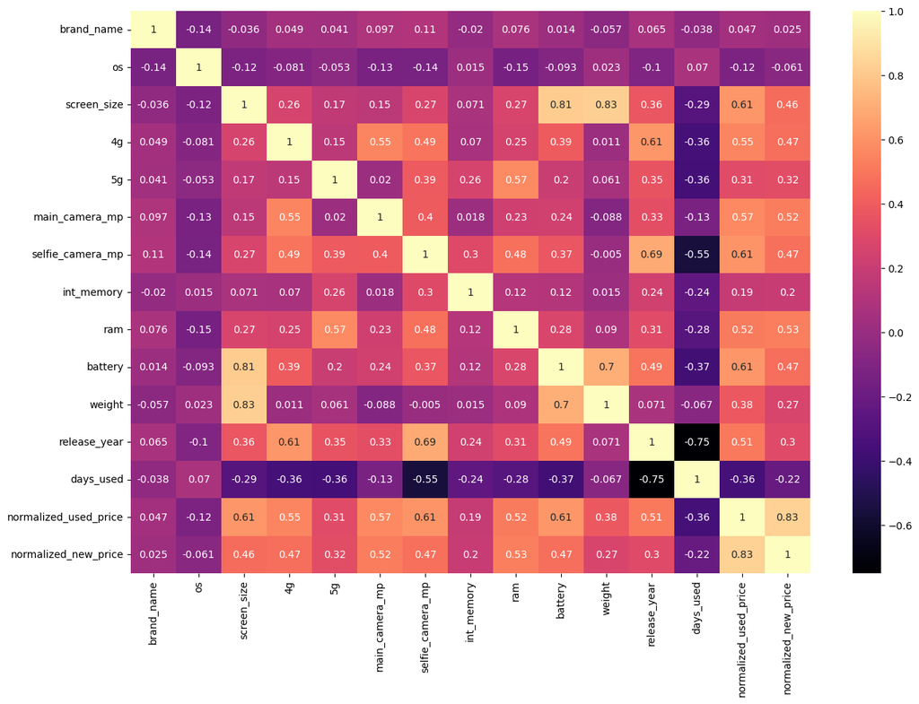

```python
fig=plt.figure(figsize=(15,10))
sns.heatmap(df.corr(method='pearson'), annot=True, cmap="magma")
plt.show()
```

#### The following variables have the higher positive correlation with the normalized price of the used devices: Screen size, Selfie camera mp and Battery. After this ones, in descending order next variables have also a positive correlation: Main camera mp, 4g, ram and release year. In the other hand, the variable with highest negative correlation is Days used.

```python
df.columns
```

```
Index(['brand_name', 'os', 'screen_size', '4g', '5g', 'main_camera_mp',
       'selfie_camera_mp', 'int_memory', 'ram', 'battery', 'weight',
       'release_year', 'days_used', 'normalized_used_price',
       'normalized_new_price'],
      dtype='object')
```

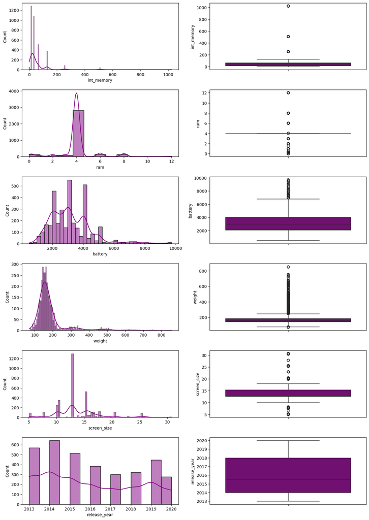

```python
axs, figure = plt.subplots(6, 2, figsize=(15, 22))
plt.subplots_adjust(hspace=0.3)
sns.histplot(df['int_memory'], ax=figure[0][0], kde=True, color="purple")
sns.boxplot(df['int_memory'], ax=figure[0][1], color="purple")
sns.histplot(df['ram'], ax=figure[1][0], kde=True, color="purple")
sns.boxplot(df['ram'], ax=figure[1][1], color="purple")
sns.histplot(df['battery'], ax=figure[2][0], kde=True, color="purple")
sns.boxplot(df['battery'], ax=figure[2][1], color="purple")
sns.histplot(df['weight'], ax=figure[3][0], kde=True, color="purple")
sns.boxplot(df['weight'], ax=figure[3][1], color="purple")
sns.histplot(df['screen_size'], ax=figure[4][0], kde=True, color="purple")
sns.boxplot(df['screen_size'], ax=figure[4][1], color="purple")
sns.histplot(df['release_year'], ax=figure[5][0], kde=True, color="purple")
sns.boxplot(df['release_year'], ax=figure[5][1], color="purple")
plt.show()
```

```python
df
```

|  | brand_name | os | screen_size | 4g | 5g | main_camera_mp | selfie_camera_mp | int_memory | ram | battery | weight | release_year | days_used | normalized_used_price | normalized_new_price |
| --- | --- | --- | --- | --- | --- | --- | --- | --- | --- | --- | --- | --- | --- | --- | --- |
| 0 | 10 | 0 | 14.50 | 1 | 0 | 13.000000 | 5.0 | 64.0 | 3.0 | 3020.0 | 146.0 | 2020 | 127 | 4.307572 | 4.715100 |
| 1 | 10 | 0 | 17.30 | 1 | 1 | 13.000000 | 16.0 | 128.0 | 8.0 | 4300.0 | 213.0 | 2020 | 325 | 5.162097 | 5.519018 |
| 2 | 10 | 0 | 16.69 | 1 | 1 | 13.000000 | 8.0 | 128.0 | 8.0 | 4200.0 | 213.0 | 2020 | 162 | 5.111084 | 5.884631 |
| 3 | 10 | 0 | 25.50 | 1 | 1 | 13.000000 | 8.0 | 64.0 | 6.0 | 7250.0 | 480.0 | 2020 | 345 | 5.135387 | 5.630961 |
| 4 | 10 | 0 | 15.32 | 1 | 0 | 13.000000 | 8.0 | 64.0 | 3.0 | 5000.0 | 185.0 | 2020 | 293 | 4.389995 | 4.947837 |
| ... | ... | ... | ... | ... | ... | ... | ... | ... | ... | ... | ... | ... | ... | ... | ... |
| 3449 | 3 | 0 | 15.34 | 1 | 0 | 9.460208 | 8.0 | 64.0 | 6.0 | 5000.0 | 190.0 | 2019 | 232 | 4.492337 | 6.483872 |
| 3450 | 3 | 0 | 15.24 | 1 | 0 | 13.000000 | 8.0 | 128.0 | 8.0 | 4000.0 | 200.0 | 2018 | 541 | 5.037732 | 6.251538 |
| 3451 | 1 | 0 | 15.80 | 1 | 0 | 13.000000 | 5.0 | 32.0 | 3.0 | 4000.0 | 165.0 | 2020 | 201 | 4.357350 | 4.528829 |
| 3452 | 1 | 0 | 15.80 | 1 | 0 | 13.000000 | 5.0 | 32.0 | 2.0 | 4000.0 | 160.0 | 2020 | 149 | 4.349762 | 4.624188 |
| 3453 | 1 | 0 | 12.83 | 1 | 0 | 13.000000 | 5.0 | 16.0 | 2.0 | 4000.0 | 168.0 | 2020 | 176 | 4.132122 | 4.279994 |

3454 rows × 15 columns

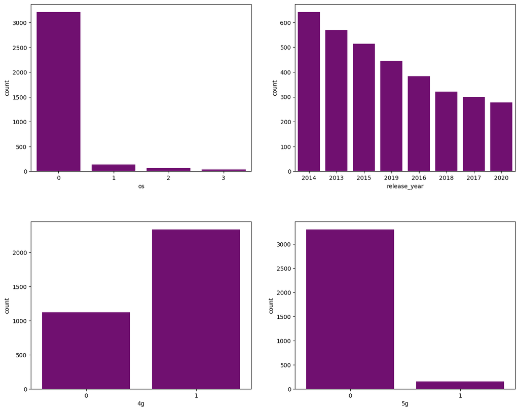

```python
axs, figure = plt.subplots(2, 2, figsize=(15, 12))
plt.subplots_adjust(hspace = 0.3)
sns.countplot(x='os', data=df, ax=figure[0, 0], color= "purple")
sns.countplot(x='4g', data=df, ax=figure[1, 0], color= "purple")
sns.countplot(x='5g', data=df, ax=figure[1, 1], color= "purple")
sns.countplot(x='release_year', data=df, ax=figure[0, 1], color= "purple", order= df['release_year'].value_counts().index)
plt.show()
```

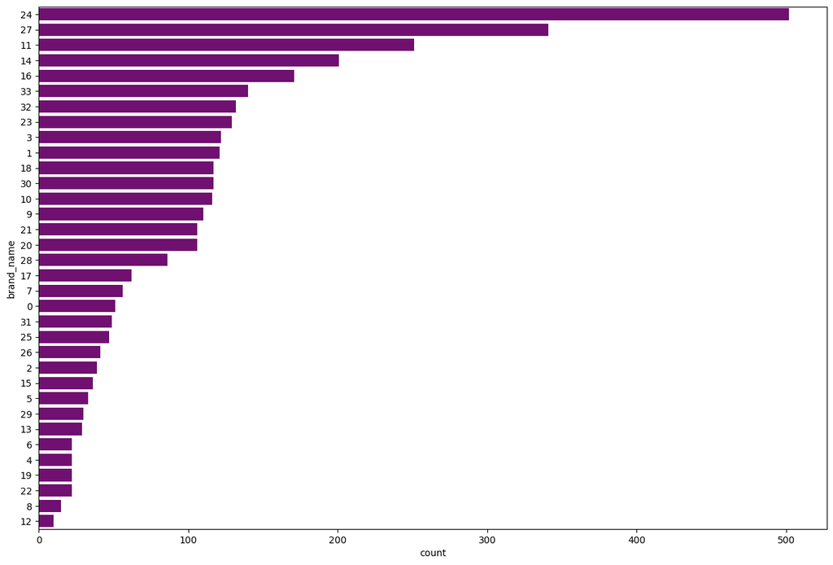

```python
fig, ax = plt.subplots(figsize=(15,10))
sns.countplot(y='brand_name', data=df, ax=ax, color= "purple", order= df['brand_name'].value_counts().index)
plt.show()
```

```python
df["brand_price_used_mean"] = df.groupby("brand_name")["normalized_used_price"].transform("mean")
df["brand_price_new_mean"] = df.groupby("brand_name")["normalized_new_price"].transform("mean")
```

## Model Building - Linear Regression

```python
df.columns
```

```
Index(['brand_name', 'os', 'screen_size', '4g', '5g', 'main_camera_mp',
       'selfie_camera_mp', 'int_memory', 'ram', 'battery', 'weight',
       'release_year', 'days_used', 'normalized_used_price',
       'normalized_new_price', 'brand_price_used_mean',
       'brand_price_new_mean'],
      dtype='object')
```

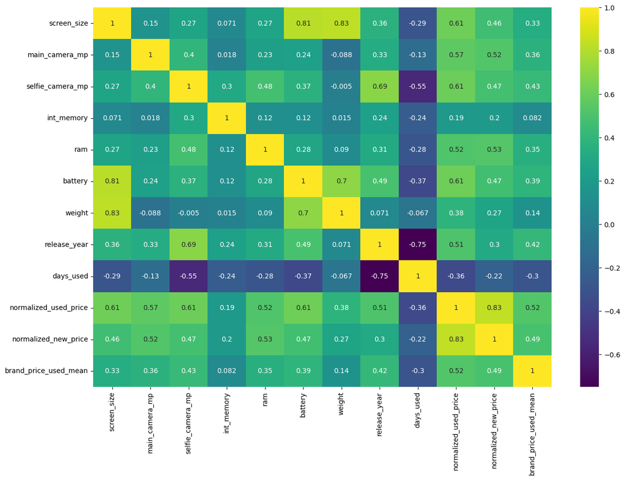

```python
fig, ax = plt.subplots(figsize=(15, 10))
sns.heatmap(df[['screen_size', 'main_camera_mp',
       'selfie_camera_mp', 'int_memory', 'ram', 'battery', 'weight',
       'release_year', 'days_used', 'normalized_used_price',
       'normalized_new_price', 'brand_price_used_mean']].corr(), annot=True, cmap="viridis")
plt.show()
```

```python
from sklearn.preprocessing import LabelEncoder
le = LabelEncoder()
categorical_cols = ['brand_name', 'os', "4g", "5g", "release_year"]
for col in categorical_cols:
    df[col] = le.fit_transform(df[col])
df.head()
```

|  | brand_name | os | screen_size | 4g | 5g | main_camera_mp | selfie_camera_mp | int_memory | ram | battery | weight | release_year | days_used | normalized_used_price | normalized_new_price | brand_price_used_mean | brand_price_new_mean |
| --- | --- | --- | --- | --- | --- | --- | --- | --- | --- | --- | --- | --- | --- | --- | --- | --- | --- |
| 0 | 10 | 0 | 14.50 | 1 | 0 | 13.0 | 5.0 | 64.0 | 3.0 | 3020.0 | 146.0 | 7 | 127 | 4.307572 | 4.715100 | 4.665257 | 5.349602 |
| 1 | 10 | 0 | 17.30 | 1 | 1 | 13.0 | 16.0 | 128.0 | 8.0 | 4300.0 | 213.0 | 7 | 325 | 5.162097 | 5.519018 | 4.665257 | 5.349602 |
| 2 | 10 | 0 | 16.69 | 1 | 1 | 13.0 | 8.0 | 128.0 | 8.0 | 4200.0 | 213.0 | 7 | 162 | 5.111084 | 5.884631 | 4.665257 | 5.349602 |
| 3 | 10 | 0 | 25.50 | 1 | 1 | 13.0 | 8.0 | 64.0 | 6.0 | 7250.0 | 480.0 | 7 | 345 | 5.135387 | 5.630961 | 4.665257 | 5.349602 |
| 4 | 10 | 0 | 15.32 | 1 | 0 | 13.0 | 8.0 | 64.0 | 3.0 | 5000.0 | 185.0 | 7 | 293 | 4.389995 | 4.947837 | 4.665257 | 5.349602 |

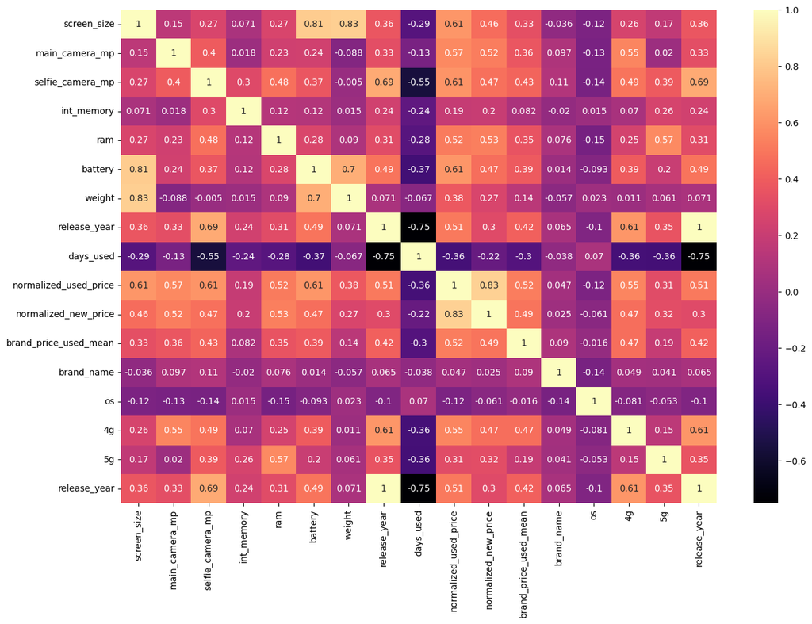

```python
fig, ax = plt.subplots(figsize=(15, 10))
sns.heatmap(df[['screen_size', 'main_camera_mp',
       'selfie_camera_mp', 'int_memory', 'ram', 'battery', 'weight',
       'release_year', 'days_used', 'normalized_used_price',
       'normalized_new_price', 'brand_price_used_mean','brand_name', 'os', "4g", "5g", "release_year"]].corr(), annot=True, cmap="magma")
plt.show()
```

```python
from sklearn.model_selection import train_test_split
from sklearn.linear_model import LinearRegression
from sklearn.metrics import mean_squared_error, r2_score, mean_absolute_error
from sklearn.preprocessing import StandardScaler
X_train, X_test, y_train, y_test = train_test_split(df[['screen_size', 'main_camera_mp',
       'selfie_camera_mp', 'int_memory', 'ram', 'battery', 'weight',
       'release_year', 'days_used',
      "4g", "5g"]], df['normalized_used_price'], test_size=0.2, random_state=42)

# Escalar los datos
#scaler = StandardScaler()
#X_train = scaler.fit_transform(X_train)
#X_test = scaler.transform(X_test)

model = LinearRegression()
model.fit(X_train, y_train)
y_pred = model.predict(X_test)
mae = mean_absolute_error(y_test, y_pred)
r2 = r2_score(y_test, y_pred)
print("Mean Absolute Error:", mae)
print("R-squared:", r2)
```

```
Mean Absolute Error: 0.21607050763351554
R-squared: 0.7371801001302047
```

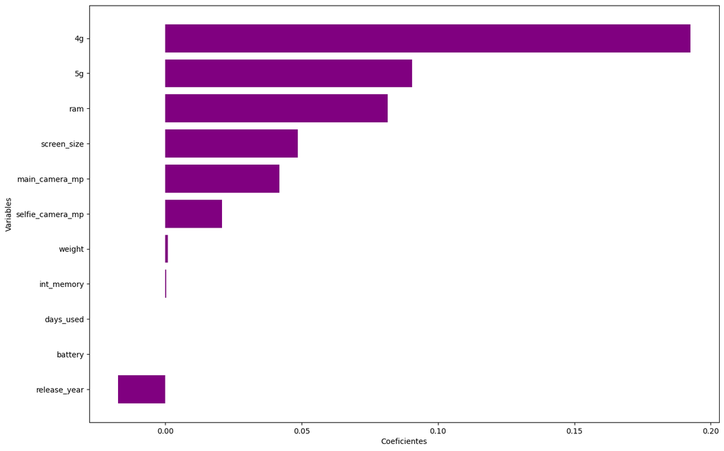

```python
import matplotlib.pyplot as plt
import numpy as np
sorted_indices = np.argsort(model.coef_)
fig = plt.figure(figsize=(15, 10))
plt.barh(X_train.columns[sorted_indices], model.coef_[sorted_indices], color="purple")
plt.xlabel("Coeficientes")
plt.ylabel("Variables")
plt.show()
```

## Checking Linear Regression Assumptions

- In order to make statistical inferences from a linear regression model, it is important to ensure that the assumptions of linear regression are satisfied.

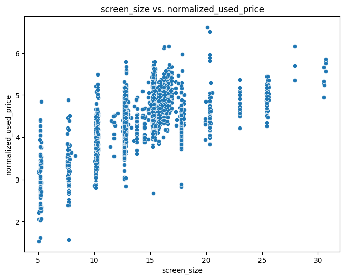

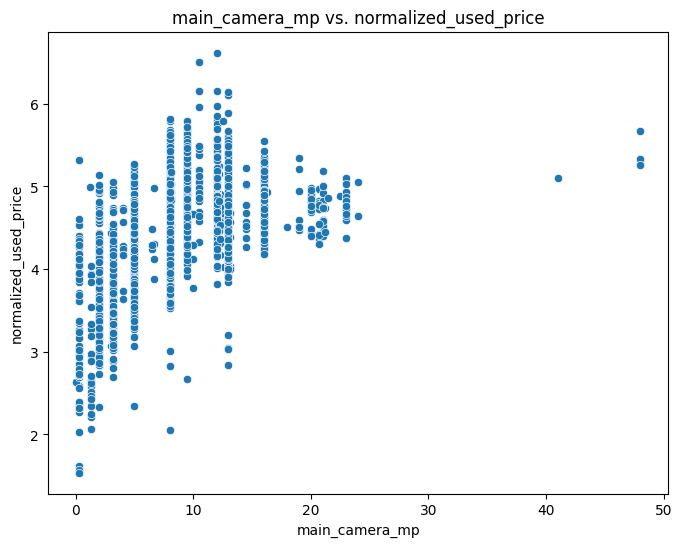

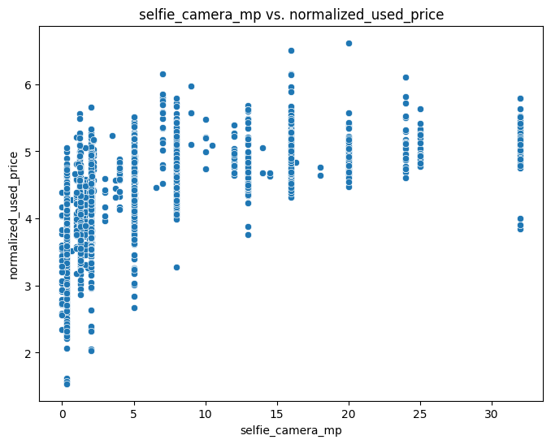

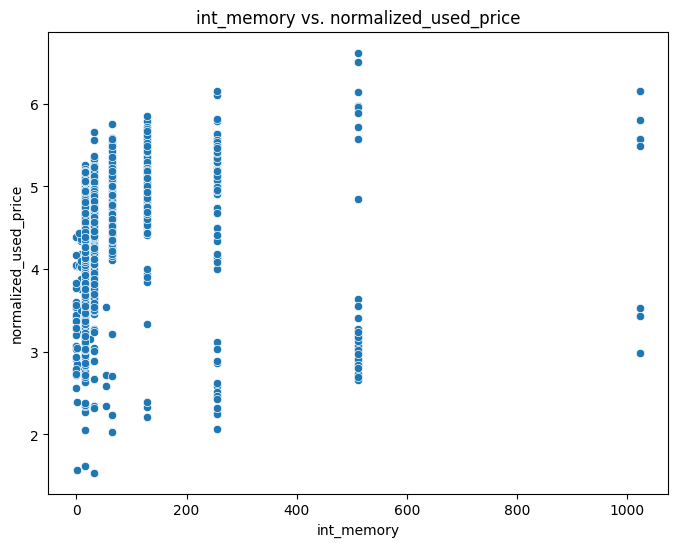

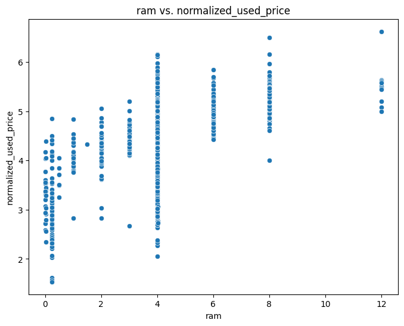

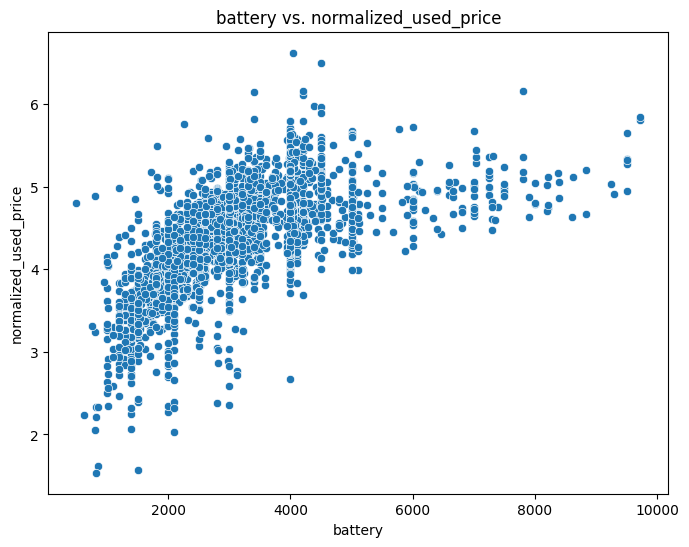

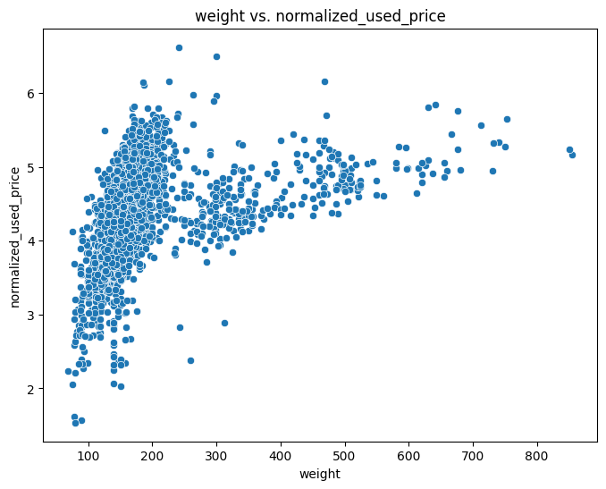

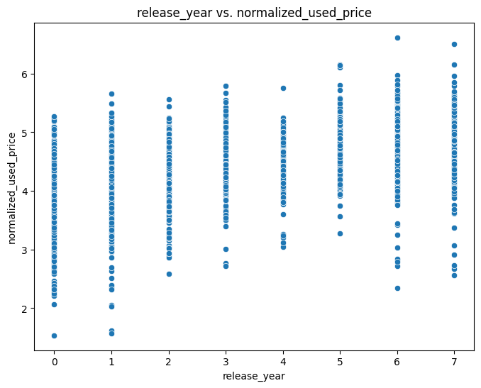

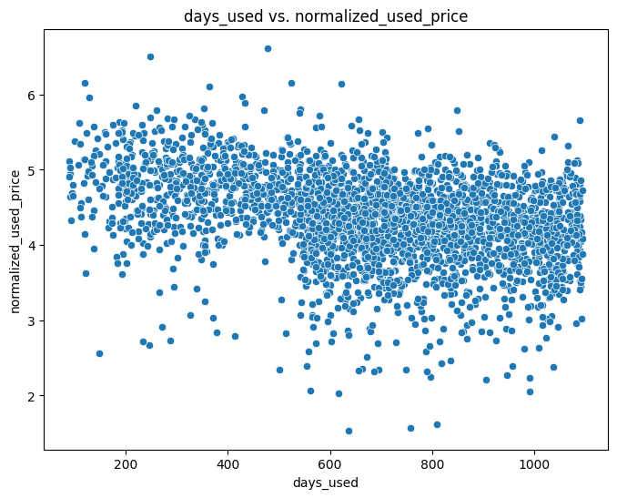

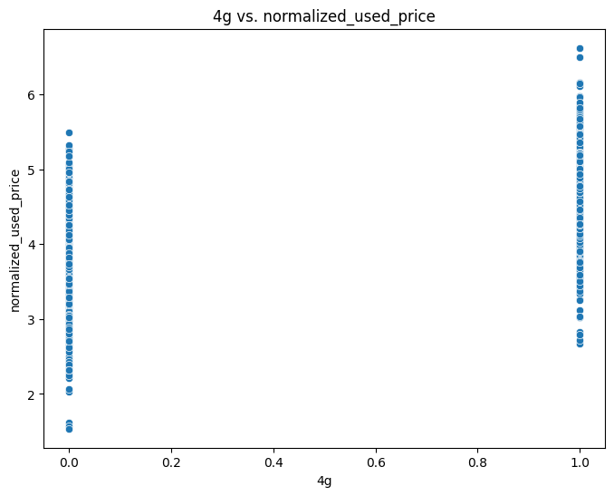

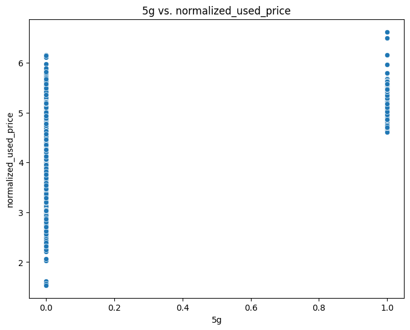

```python
import matplotlib.pyplot as plt
import seaborn as sns

# Assuming 'df' is your DataFrame
for feature in X_train.columns:
    plt.figure(figsize=(8, 6))
    sns.scatterplot(x=X_train[feature], y=y_train)
    plt.title(f'{feature} vs. normalized_used_price')
    plt.xlabel(feature)
    plt.ylabel('normalized_used_price')
    plt.show()
```

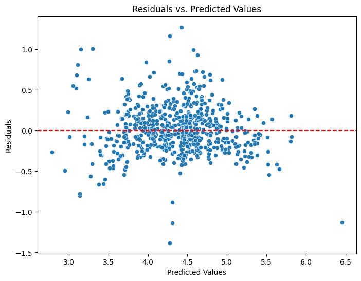

```python
import matplotlib.pyplot as plt
import seaborn as sns

residuals = y_test - y_pred

plt.figure(figsize=(8, 6))
sns.scatterplot(x=y_pred, y=residuals)
plt.title('Residuals vs. Predicted Values')
plt.xlabel('Predicted Values')
plt.ylabel('Residuals')
plt.axhline(y=0, color='red', linestyle='--')  # Add a horizontal line at 0
plt.show()
```

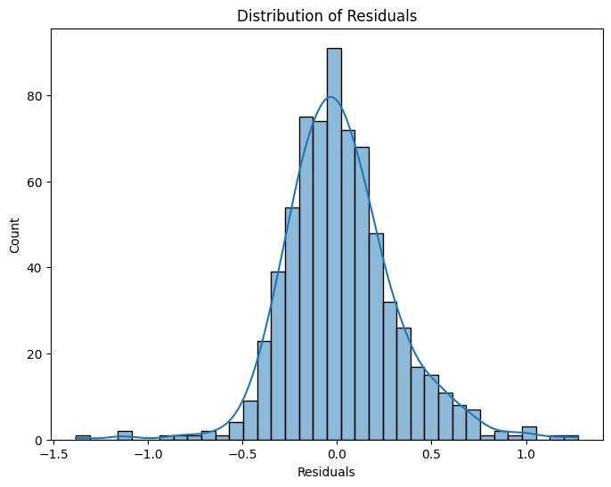

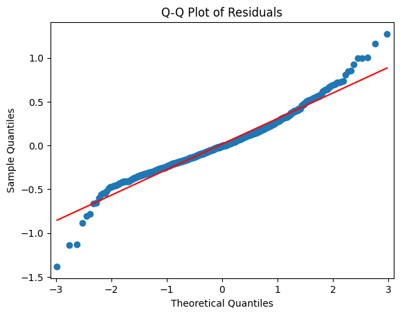

```python
import matplotlib.pyplot as plt
import seaborn as sns
import statsmodels.api as sm

plt.figure(figsize=(8, 6))
sns.histplot(residuals, kde=True)
plt.title('Distribution of Residuals')
plt.xlabel('Residuals')
plt.show()

# Q-Q plot
fig = sm.qqplot(residuals, line='s')
plt.title('Q-Q Plot of Residuals')
plt.show()
```

```python
from statsmodels.stats.stattools import durbin_watson

dw_statistic = durbin_watson(residuals)
print(f"Durbin-Watson statistic: {dw_statistic}")
```

```
Durbin-Watson statistic: 1.9678245108059185
```

```python
import pandas as pd
from statsmodels.stats.outliers_influence import variance_inflation_factor

# Assuming 'X_train' is your DataFrame of independent variables
corr_matrix = X_train.corr()

# Calculate VIF
vif_data = pd.DataFrame()
vif_data["Variable"] = X_train.columns
vif_data["VIF"] = [variance_inflation_factor(X_train.values, i) for i in range(X_train.shape[1])]
vif_data
```

|  | Variable | VIF |
| --- | --- | --- |
| 0 | screen_size | 74.538581 |
| 1 | main_camera_mp | 8.474549 |
| 2 | selfie_camera_mp | 4.624337 |
| 3 | int_memory | 1.587765 |
| 4 | ram | 16.093508 |
| 5 | battery | 26.868592 |
| 6 | weight | 27.968899 |
| 7 | release_year | 9.037031 |
| 8 | days_used | 9.430014 |
| 9 | 4g | 6.557940 |
| 10 | 5g | 1.742096 |

## Final Model

```python
df["Physical_Atributes"] = df["screen_size"] + df["weight"]
df["MemBat_Atributes"] = (df["ram"] / df["battery"])
df["Cameras_Atributes"] = (df["main_camera_mp"] + df["selfie_camera_mp"])  * df["4g"]
df["Time_Atributes"] = df["release_year"]/df["days_used"]
df
```

|  | brand_name | os | screen_size | 4g | 5g | main_camera_mp | selfie_camera_mp | int_memory | ram | battery | ... | release_year | days_used | normalized_used_price | normalized_new_price | brand_price_used_mean | brand_price_new_mean | Physical_Atributes | MemBat_Atributes | Cameras_Atributes | Time_Atributes |
| --- | --- | --- | --- | --- | --- | --- | --- | --- | --- | --- | --- | --- | --- | --- | --- | --- | --- | --- | --- | --- | --- |
| 0 | 10 | 0 | 14.50 | 1 | 0 | 13.000000 | 5.0 | 64.0 | 3.0 | 3020.0 | ... | 7 | 127 | 4.307572 | 4.715100 | 4.665257 | 5.349602 | 160.50 | 0.000993 | 18.000000 | 0.055118 |
| 1 | 10 | 0 | 17.30 | 1 | 1 | 13.000000 | 16.0 | 128.0 | 8.0 | 4300.0 | ... | 7 | 325 | 5.162097 | 5.519018 | 4.665257 | 5.349602 | 230.30 | 0.001860 | 29.000000 | 0.021538 |
| 2 | 10 | 0 | 16.69 | 1 | 1 | 13.000000 | 8.0 | 128.0 | 8.0 | 4200.0 | ... | 7 | 162 | 5.111084 | 5.884631 | 4.665257 | 5.349602 | 229.69 | 0.001905 | 21.000000 | 0.043210 |
| 3 | 10 | 0 | 25.50 | 1 | 1 | 13.000000 | 8.0 | 64.0 | 6.0 | 7250.0 | ... | 7 | 345 | 5.135387 | 5.630961 | 4.665257 | 5.349602 | 505.50 | 0.000828 | 21.000000 | 0.020290 |
| 4 | 10 | 0 | 15.32 | 1 | 0 | 13.000000 | 8.0 | 64.0 | 3.0 | 5000.0 | ... | 7 | 293 | 4.389995 | 4.947837 | 4.665257 | 5.349602 | 200.32 | 0.000600 | 21.000000 | 0.023891 |
| ... | ... | ... | ... | ... | ... | ... | ... | ... | ... | ... | ... | ... | ... | ... | ... | ... | ... | ... | ... | ... | ... |
| 3449 | 3 | 0 | 15.34 | 1 | 0 | 9.460208 | 8.0 | 64.0 | 6.0 | 5000.0 | ... | 6 | 232 | 4.492337 | 6.483872 | 4.510720 | 5.387590 | 205.34 | 0.001200 | 17.460208 | 0.025862 |
| 3450 | 3 | 0 | 15.24 | 1 | 0 | 13.000000 | 8.0 | 128.0 | 8.0 | 4000.0 | ... | 5 | 541 | 5.037732 | 6.251538 | 4.510720 | 5.387590 | 215.24 | 0.002000 | 21.000000 | 0.009242 |
| 3451 | 1 | 0 | 15.80 | 1 | 0 | 13.000000 | 5.0 | 32.0 | 3.0 | 4000.0 | ... | 7 | 201 | 4.357350 | 4.528829 | 3.970264 | 4.804302 | 180.80 | 0.000750 | 18.000000 | 0.034826 |
| 3452 | 1 | 0 | 15.80 | 1 | 0 | 13.000000 | 5.0 | 32.0 | 2.0 | 4000.0 | ... | 7 | 149 | 4.349762 | 4.624188 | 3.970264 | 4.804302 | 175.80 | 0.000500 | 18.000000 | 0.046980 |
| 3453 | 1 | 0 | 12.83 | 1 | 0 | 13.000000 | 5.0 | 16.0 | 2.0 | 4000.0 | ... | 7 | 176 | 4.132122 | 4.279994 | 3.970264 | 4.804302 | 180.83 | 0.000500 | 18.000000 | 0.039773 |

3454 rows × 21 columns

```python
from sklearn.model_selection import train_test_split
from sklearn.linear_model import LinearRegression
from sklearn.metrics import mean_squared_error, r2_score
from sklearn.preprocessing import StandardScaler

X_train, X_test, y_train, y_test = train_test_split(df[["Physical_Atributes","MemBat_Atributes","Cameras_Atributes",
         "5g", "Time_Atributes", "int_memory"]], df['normalized_used_price'], test_size=0.2, random_state=42)
#scaler = StandardScaler()
#X_train = scaler.fit_transform(X_train)
#X_test = scaler.transform(X_test)

# Entrenar y evaluar el modelo
model = LinearRegression()
model.fit(X_train, y_train)
y_pred = model.predict(X_test)
mae = mean_absolute_error(y_test, y_pred)
r2 = r2_score(y_test, y_pred)
print("Mean Absolute Error:", mae)
print("R-squared:", r2)
```

```
Mean Absolute Error: 0.2616795039730211
R-squared: 0.6159326179726753
```

```python
import pandas as pd
from statsmodels.stats.outliers_influence import variance_inflation_factor

# Calculate VIF
vif_data = pd.DataFrame()
vif_data["Variable"] = X_train.columns
vif_data["VIF"] = [variance_inflation_factor(X_train.values, i) for i in range(X_train.shape[1])]
vif_data
```

|  | Variable | VIF |
| --- | --- | --- |
| 0 | Physical_Atributes | 2.990012 |
| 1 | MemBat_Atributes | 2.516237 |
| 2 | Cameras_Atributes | 2.766448 |
| 3 | 5g | 1.364175 |
| 4 | Time_Atributes | 2.360016 |
| 5 | int_memory | 1.522749 |

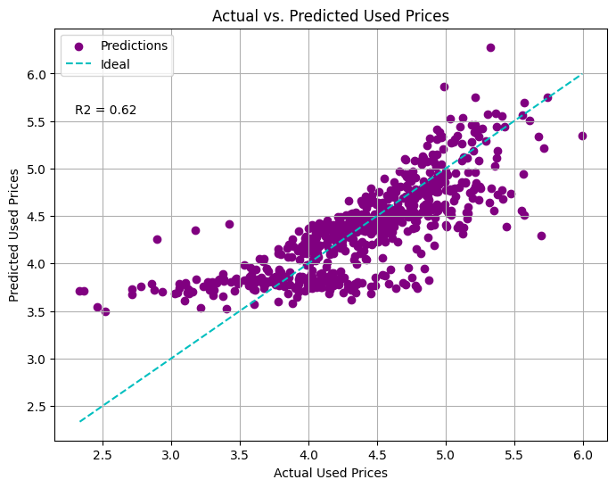

```python
plt.figure(figsize=(8, 6))
plt.scatter(y_test, y_pred, color = "purple", label ="Predictions")
plt.plot([min(y_test), max(y_test)], [min(y_test), max(y_test)], linestyle='--', color='c', label="Ideal")
plt.title('Actual vs. Predicted Used Prices')
plt.xlabel('Actual Used Prices')
plt.ylabel('Predicted Used Prices')
plt.text(2.3,5.58,f"R2 = {round(r2_score(y_test, y_pred),2)}")
plt.grid(True)
plt.legend(loc="best")
plt.show()
```

## Actionable Insights and Recommendations

#### -Despite finding a balance between the overfitting caused by multicollinearity and the model's performance, the linear regression gives us an R² of 0.62. Therefore, it is advisable to explore other models or alternative strategies beyond feature engineering, such as regularization.

#### -According to the analysis of the coefficients and their direct impact on the price of the device, the variables 4g, 5g, ram, screen size and main camera are highlighted in descending order. The above will allow determining the weight of the characteristics on the price.